# 项目：巴西预约挂号数据集分析

## 目录

- 简介
- 数据整理
- 探索性数据分析
- 结论

## 一. 简介

本数据集包含10万条巴西预约挂号的求诊信息(来自[Kaggle](https://www.kaggle.com/joniarroba/noshowappointments)的原始数据)，研究病人是否如约前往医院就诊。每行数据录入了有关患者特点的多个数值，包括 “预约日期 (ScheduledDay)”指患者具体预约就诊的日期；“街区 (Neighborhood) ”指医院所在位置；“福利保障 (Scholarship)”说明病人是否是巴西福利项目Bolsa Família的保障人群；最后一列内容：“No”表示病人已如约就诊，“Yes”说明病人未前往就诊。

该项目拟研究：

- 一周内随着日期的不同，预约数量如何变化？
- 预约人群的年龄分布如何？不同性别的年龄分布又如何，是否有差异？
- 哪种性别的患者预约数量更多
- 哪些因素能够帮助预测患者是否会按照其挂号预约前往医院就诊？其中哪些因素影响显著，哪些因素影响较弱？

```python
# 导入需要用到的包
import pandas as pd
import matplotlib.pyplot as plt
import seaborn as sns
sns.set()

# 数据可视化相关设置
%matplotlib inline
%config InlineBackend.figure_format = 'retina'
```

## 二. 数据整理

本数据集需要进行的清理工作包括：

- 清理列标签
- 丢空，去重，去除异常值
- 检查数据类型
- 提取特征值

```python
# 读取数据
data = pd.read_csv('KaggleV2-May-2016.csv')
# 打印前三行
data.head(3)
```

|  | PatientId | AppointmentID | Gender | ScheduledDay | AppointmentDay | Age | Neighbourhood | Scholarship | Hipertension | Diabetes | Alcoholism | Handcap | SMS_received | No-show |
| --- | --- | --- | --- | --- | --- | --- | --- | --- | --- | --- | --- | --- | --- | --- |
| 0 | 2.987250e+13 | 5642903 | F | 2016-04-29T18:38:08Z | 2016-04-29T00:00:00Z | 62 | JARDIM DA PENHA | 0 | 1 | 0 | 0 | 0 | 0 | No |
| 1 | 5.589978e+14 | 5642503 | M | 2016-04-29T16:08:27Z | 2016-04-29T00:00:00Z | 56 | JARDIM DA PENHA | 0 | 0 | 0 | 0 | 0 | 0 | No |
| 2 | 4.262962e+12 | 5642549 | F | 2016-04-29T16:19:04Z | 2016-04-29T00:00:00Z | 62 | MATA DA PRAIA | 0 | 0 | 0 | 0 | 0 | 0 | No |

```python
# 数据集大小
data.shape
```

```
(110527, 14)
```

### 2.1 清理列标签

将列标签统一改为小写字母，并且改正其中的拼写错误。

```python
# 将大写字母转为小写字母，将中横线转为下划线
data.columns = data.columns.str.lower().str.replace('-','_')
print(data.columns)

# 两个单词之间添加下划线，改正拼写错误
cols = {'patientid':'patient_id', 'appointmentid':'appointment_id', 'scheduledday':'scheduled_day', 'appointmentday':'appointment_day', 'hipertension':'hypertension', 'handcap':'handicap'}
data.rename(columns=cols, inplace=True)
print(data.columns)
```

```
Index(['patientid', 'appointmentid', 'gender', 'scheduledday',
       'appointmentday', 'age', 'neighbourhood', 'scholarship', 'hipertension',
       'diabetes', 'alcoholism', 'handcap', 'sms_received', 'no_show'],
      dtype='object')
Index(['patient_id', 'appointment_id', 'gender', 'scheduled_day',
       'appointment_day', 'age', 'neighbourhood', 'scholarship',
       'hypertension', 'diabetes', 'alcoholism', 'handicap', 'sms_received',
       'no_show'],
      dtype='object')
```

### 2.2 检查数据类型

将表示时间的数据改为时间类型。

```python
data.head(3)
```

|  | patient_id | appointment_id | gender | scheduled_day | appointment_day | age | neighbourhood | scholarship | hypertension | diabetes | alcoholism | handicap | sms_received | no_show |
| --- | --- | --- | --- | --- | --- | --- | --- | --- | --- | --- | --- | --- | --- | --- |
| 0 | 2.987250e+13 | 5642903 | F | 2016-04-29T18:38:08Z | 2016-04-29T00:00:00Z | 62 | JARDIM DA PENHA | 0 | 1 | 0 | 0 | 0 | 0 | No |
| 1 | 5.589978e+14 | 5642503 | M | 2016-04-29T16:08:27Z | 2016-04-29T00:00:00Z | 56 | JARDIM DA PENHA | 0 | 0 | 0 | 0 | 0 | 0 | No |
| 2 | 4.262962e+12 | 5642549 | F | 2016-04-29T16:19:04Z | 2016-04-29T00:00:00Z | 62 | MATA DA PRAIA | 0 | 0 | 0 | 0 | 0 | 0 | No |

```python
# 查看数据类型
data.dtypes
```

```
patient_id         float64
appointment_id       int64
gender              object
scheduled_day       object
appointment_day     object
age                  int64
neighbourhood       object
scholarship          int64
hypertension         int64
diabetes             int64
alcoholism           int64
handicap             int64
sms_received         int64
no_show             object
dtype: object
```

```python
# 转换时间类型
data['scheduled_day'] = pd.to_datetime(data['scheduled_day'])
data['appointment_day'] = pd.to_datetime(data['appointment_day'])

print(data['scheduled_day'].head(3))
print(data['appointment_day'].head(3))
```

```
0   2016-04-29 18:38:08
1   2016-04-29 16:08:27
2   2016-04-29 16:19:04
Name: scheduled_day, dtype: datetime64[ns]
0   2016-04-29
1   2016-04-29
2   2016-04-29
Name: appointment_day, dtype: datetime64[ns]
```

### 2.3 丢空，去重，去除异常值

检查数据中是否存在缺失值，重复值和异常值。经检查发现没有重复值和缺失值，只有异常值。

```python
# 查看是否有重复值
sum(data.duplicated())
```

```
0
```

无重复值。

```python
# 查看是否有缺失数据或异常数据
print(data.info()) # 不同值的个数
print('---------')
print('gender', data['gender'].unique())
print('age', sorted(data['age'].unique()))
print('scholarship', data['scholarship'].unique())
print('hypertension', data['hypertension'].unique())
print('diabetes', data['diabetes'].unique())
print('alcoholism', data['alcoholism'].unique())
print('handicap', data['handicap'].unique())
print('sms_received', data['sms_received'].unique())
print('no_show', data['no_show'].unique())
```

```
<class 'pandas.core.frame.DataFrame'>
RangeIndex: 110527 entries, 0 to 110526
Data columns (total 14 columns):
patient_id         110527 non-null float64
appointment_id     110527 non-null int64
gender             110527 non-null object
scheduled_day      110527 non-null datetime64[ns]
appointment_day    110527 non-null datetime64[ns]
age                110527 non-null int64
neighbourhood      110527 non-null object
scholarship        110527 non-null int64
hypertension       110527 non-null int64
diabetes           110527 non-null int64
alcoholism         110527 non-null int64
handicap           110527 non-null int64
sms_received       110527 non-null int64
no_show            110527 non-null object
dtypes: datetime64[ns](2), float64(1), int64(8), object(3)
memory usage: 11.8+ MB
None
---------
gender ['F' 'M']
age [-1, 0, 1, 2, 3, 4, 5, 6, 7, 8, 9, 10, 11, 12, 13, 14, 15, 16, 17, 18, 19, 20, 21, 22, 23, 24, 25, 26, 27, 28, 29, 30, 31, 32, 33, 34, 35, 36, 37, 38, 39, 40, 41, 42, 43, 44, 45, 46, 47, 48, 49, 50, 51, 52, 53, 54, 55, 56, 57, 58, 59, 60, 61, 62, 63, 64, 65, 66, 67, 68, 69, 70, 71, 72, 73, 74, 7…
scholarship [0 1]
hypertension [1 0]
diabetes [0 1]
alcoholism [0 1]
handicap [0 1 2 3 4]
sms_received [0 1]
no_show ['No' 'Yes']
```

很明显，没有空缺值，但是年龄特征中出现了异常值-1岁，查看该条数据并将其删除。

```python
# 查看异常数据
print(data[data.age == -1])
print(data[data.age == -1].shape)

# 删除异常数据
data.drop(99832, axis=0, inplace=True)
# 删除之后数据大小
print('data_shape', data.shape)
```

```
         patient_id  appointment_id gender       scheduled_day  \
99832  4.659432e+14         5775010      F 2016-06-06 08:58:13

      appointment_day  age neighbourhood  scholarship  hypertension  diabetes  \
99832      2016-06-06   -1         ROMÃO            0             0         0

       alcoholism  handicap  sms_received no_show
99832           0         0             0      No
(1, 14)
data_shape (110526, 14)
```

### 2.4 增加星期特征

从预约的就诊日期中提取星期几信息，并增加至`data`中。

**说明：**数字1到7分别对应星期一到星期日。

```python
data['day_of_week'] = data['appointment_day'].apply(lambda x: x.weekday()+1)
data.head(3)
```

|  | patient_id | appointment_id | gender | scheduled_day | appointment_day | age | neighbourhood | scholarship | hypertension | diabetes | alcoholism | handicap | sms_received | no_show | day_of_week |
| --- | --- | --- | --- | --- | --- | --- | --- | --- | --- | --- | --- | --- | --- | --- | --- |
| 0 | 2.987250e+13 | 5642903 | F | 2016-04-29 18:38:08 | 2016-04-29 | 62 | JARDIM DA PENHA | 0 | 1 | 0 | 0 | 0 | 0 | No | 5 |
| 1 | 5.589978e+14 | 5642503 | M | 2016-04-29 16:08:27 | 2016-04-29 | 56 | JARDIM DA PENHA | 0 | 0 | 0 | 0 | 0 | 0 | No | 5 |
| 2 | 4.262962e+12 | 5642549 | F | 2016-04-29 16:19:04 | 2016-04-29 | 62 | MATA DA PRAIA | 0 | 0 | 0 | 0 | 0 | 0 | No | 5 |

## 三. 探索性数据分析

### 3.1 一周内随着日期的不同，预约数量如何变化？

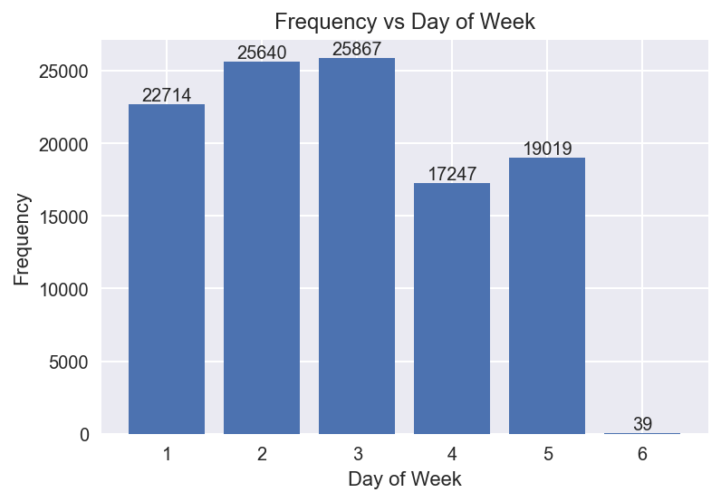

```python
# 对不同星期的数据进行统计
fig_data = data['day_of_week'].value_counts()

plt.bar(x=fig_data.index, height=fig_data)
plt.title('Frequency vs Day of Week')
plt.xlabel('Day of Week')
plt.ylabel('Frequency')

# 添加数值大小
for x,y in fig_data.items():
    plt.text(x, y, '%.0f'%y, ha='center', va= 'bottom')

plt.show()
```

观察上图可知，患者的预约集中在工作日，而周六的预约人次微乎其微，周日则没有预约。其中工作日的预约，周一到周三每天的预约人次高于周四和周五的预约人次。

### 3.2 预约人群的年龄分布如何？不同性别的年龄分布又如何，是否有差异？

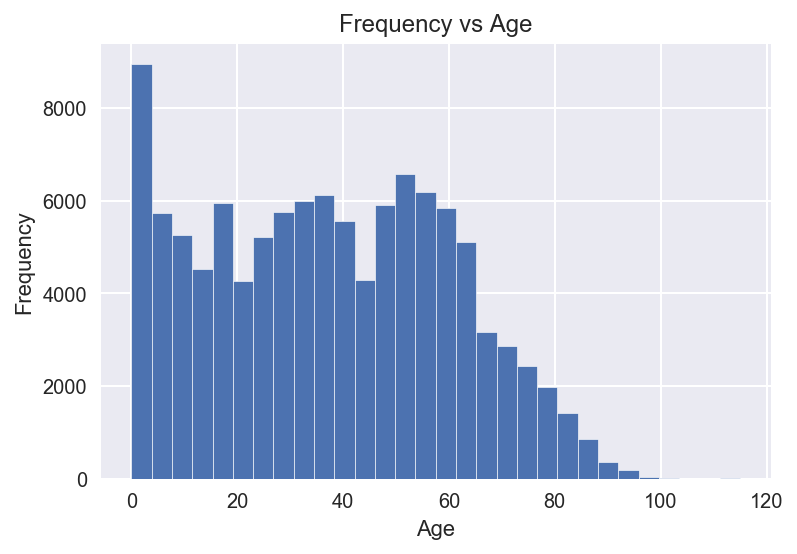

```python
data.age.hist(bins=30, edgecolor='white')
plt.title('Frequency vs Age')
plt.xlabel('Age')
plt.ylabel('Frequency');
```

预约患者的年龄分布呈右偏态分布，患者预约数量集中在0到60岁年龄段。

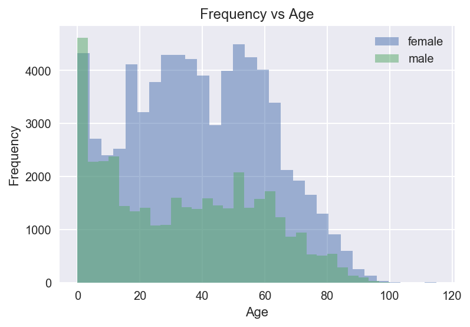

```python
data.age[data.gender == 'F'].hist(alpha=0.5, bins=30, label='female')
data.age[data.gender == 'M'].hist(alpha=0.5, bins=30, label='male')
plt.legend()
plt.title('Frequency vs Age')
plt.xlabel('Age')
plt.ylabel('Frequency');
```

不同性别的年龄分布略有差异，女性在20岁到60岁之间患者预约最多，男性在20岁以下的患者预约更频繁。

### 3.3 哪种性别的患者预约数量更多？

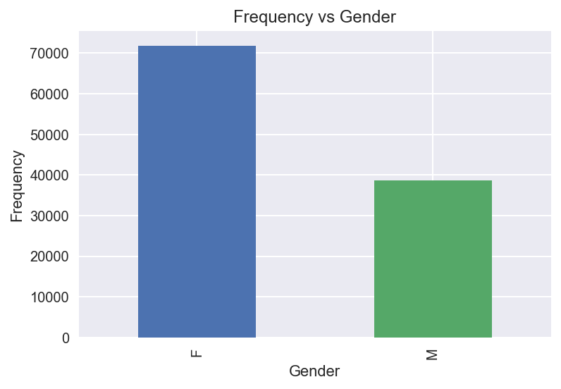

```python
data.groupby('gender').patient_id.count().plot(kind='bar')
plt.title('Frequency vs Gender')
plt.xlabel('Gender')
plt.ylabel('Frequency');
```

明显女性患者的预约人次更高，大致是男性患者的两倍。说明巴西女性相较男性而言，更关心自身的健康。

### 3.5 哪些因素影响病人是否按约就诊？

拟研究的因素包括：

- 是否收到短信提醒(sms_received)
- 是否享受福利(scholarship)
- 是否患高血压(hypertension)
- 星期几就诊(day_of_week)
- 年龄(age)
- 医院所在街区(neighbourhood)
- 是否患糖尿病(diabetes)
- 残障等级(handicap)
- 性别(gender)
- 是否酗酒(alcoholism)

下面对这些特征逐一进行研究。

```python
# 根据某一特征计算就诊率
def show_rate_by_feature(feature):
    '''
    根据某个特征计算就诊率
    '''
    raw_data = data.groupby([feature, 'no_show'])['patient_id'].count()

    # 该特征的所有不同值
    items = raw_data.index.levels[0]

    # 该特征下每个不同值的就诊率
    values = []
    for i in items:
        if 'No' in raw_data[i]:
            values.append(raw_data[i]['No']/raw_data[i].sum())
        else:
            values.append(0)

    # 构造pd.Series对象，对作图而言有用的数据
    fig_data = pd.Series(values, index=items)

    # 返回字典数据
    return {'fig_data':fig_data, 'raw_data':raw_data}
```

### 3.1 是否接到短信提醒

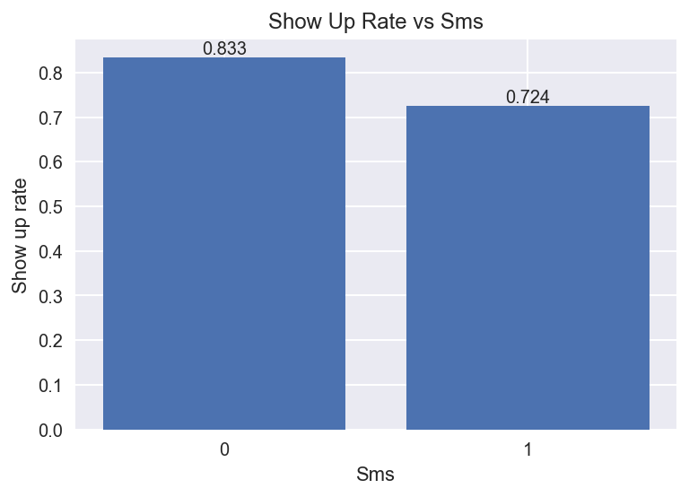

```python
# 获取数据
show_rate_by_sms = show_rate_by_feature('sms_received')
fig_data = show_rate_by_sms['fig_data']

# 画柱状图
plt.bar(x=fig_data.index, height=fig_data)
plt.title('Show Up Rate vs Sms')
plt.xlabel('Sms')
plt.xticks(range(0,2))
plt.ylabel('Show up rate')

# 添加数值大小,保留两位小数
for x,y in fig_data.items():
    plt.text(x, y, '%.3f'%y, ha='center', va= 'bottom')

plt.show()
```

没有收到短信提醒的病人比收到短信提醒的病人的就诊率高出10.9%。

### 3.2 是否享受福利保障

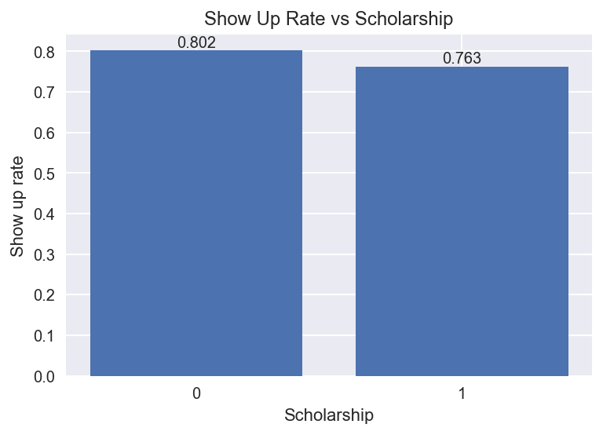

```python
# 获取数据
show_rate_by_scholarship = show_rate_by_feature('scholarship')
fig_data = show_rate_by_scholarship['fig_data']

# 画柱状图
plt.bar(x=fig_data.index, height=fig_data)
plt.title('Show Up Rate vs Scholarship')
plt.xlabel('Scholarship')
plt.xticks(range(0,2))
plt.ylabel('Show up rate')

# 添加数值大小,保留两位小数
for x,y in fig_data.items():
    plt.text(x, y, '%.3f'%y, ha='center', va= 'bottom')

plt.show()
```

没有享受福利保障的病人比享受福利保障的病人的就诊率高出3.9%。

### 3.3 是否患高血压

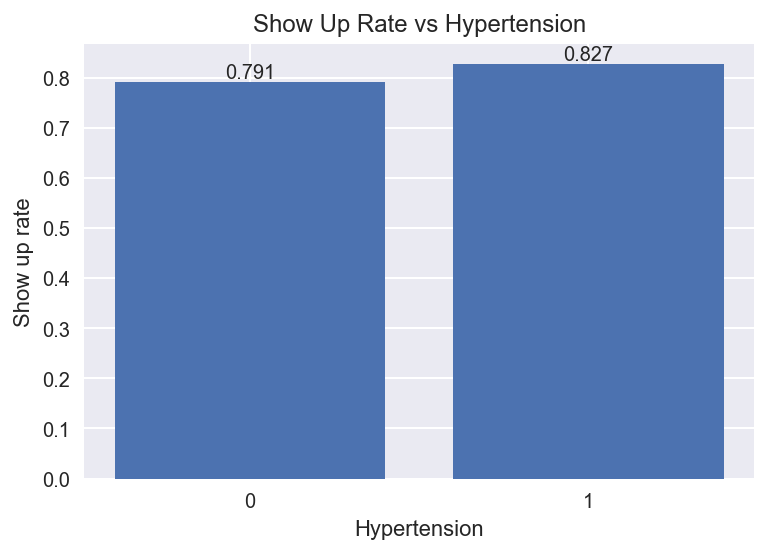

```python
# 获取数据
show_rate_by_hypertension = show_rate_by_feature('hypertension')
fig_data = show_rate_by_hypertension['fig_data']

# 画柱状图
plt.bar(x=fig_data.index, height=fig_data)
plt.title('Show Up Rate vs Hypertension')
plt.xlabel('Hypertension')
plt.xticks(range(0,2))
plt.ylabel('Show up rate')

# 添加数值大小,保留两位小数
for x,y in fig_data.items():
    plt.text(x, y, '%.3f'%y, ha='center', va= 'bottom')

plt.show()
```

高血压病人比非高血压病人的就诊率高出3.6%。

### 3.4 不同星期的就诊率

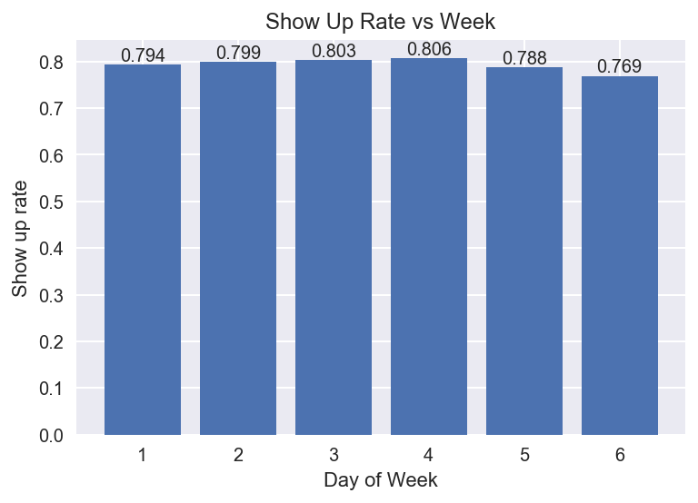

```python
# 获取数据
show_rate_by_week = show_rate_by_feature('day_of_week')
fig_data = show_rate_by_week['fig_data']

# 画柱状图
plt.bar(x=fig_data.index, height=fig_data)
plt.title('Show Up Rate vs Week')
plt.xlabel('Day of Week')
plt.ylabel('Show up rate')

# 添加数值大小,保留两位小数
for x,y in fig_data.items():
    plt.text(x, y, '%.3f'%y, ha='center', va= 'bottom')

plt.show()
```

观察上图可知，预约在工作日(周一到周五)的就诊率稍高于周六，就诊率高出1.9%-3.7%不等。

### 3.5 不同年龄的就诊率

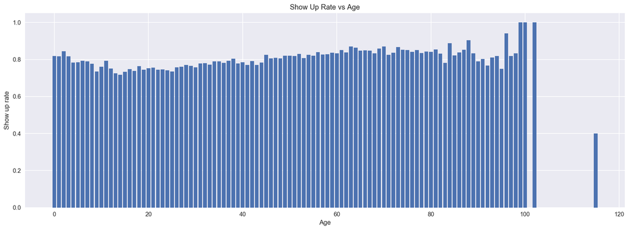

```python
# 获取数据
show_rate_by_age = show_rate_by_feature('age')
fig_data = show_rate_by_age['fig_data']

# 画柱状图
plt.figure(figsize=(18,6))
plt.bar(x=fig_data.index, height=fig_data)
plt.title('Show Up Rate vs Age')
plt.xlabel('Age')
plt.ylabel('Show up rate')
plt.show()
```

很明显在接近120岁时，就诊率异乎寻常地低，可能该处数据有异常。继续查看详细数据发现：当年龄大于93岁时，数据量过小，不足以评估真实情况，所以将这些数据过滤再进行数据可视化。

```python
# 查看详细数据
print(show_rate_by_age['raw_data'])
```

```
age  no_show
0    No         2900
     Yes         639
1    No         1858
     Yes         415
2    No         1366
     Yes         252
3    No         1236
     Yes         277
4    No         1017
     Yes         282
5    No         1169
     Yes         320
6    No         1205
     Yes         316
7    No         1126
     Yes         301
8    No         1106
     Yes         318
9    No         1008
     Yes         364
10   No          970
     Yes         304
11   No          948
     Yes         247
12   No          820
     Yes         272
13   No          800
     Yes         303
14   No          802
     Yes         316
                ...
86   Yes          42
87   No          157
     Yes          27
88   No          114
     Yes          12
89   No          144
     Yes          29
90   No           86
```

[output cut: 8 more lines]

```
     Yes           6
95   No           18
     Yes           6
96   No           16
     Yes           1
97   No            9
     Yes           2
98   No            5
     Yes           1
99   No            1
100  No            4
102  No            2
115  No            2
     Yes           3
Name: patient_id, Length: 203, dtype: int64
```

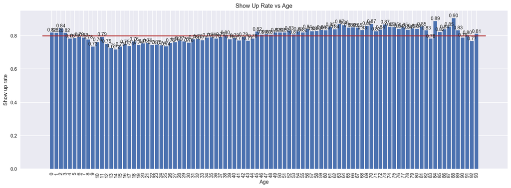

```python
# 过滤之后的数据
filter_data = fig_data[fig_data.index < 94]

# 作柱状图
plt.figure(figsize=(18,6))
plt.bar(x=filter_data.index, height=filter_data)

# 添加数值,保留两位小数
for x,y in filter_data.items():
    plt.text(x, y, '%.2f'%y, ha='center', va= 'bottom')

# 数据集就诊率
rate = len(data[data.no_show == 'No'])/len(data)
# 作参考线：与数据集的就诊率相比较
plt.plot([-2, 95], [rate, rate], color='FIREBRICK')

plt.title('Show Up Rate vs Age')
plt.xlabel('Age')
plt.xticks(range(0,94), rotation=90)
plt.ylabel('Show up rate')
plt.show()
```

```python
# 数据集就诊率
print('rate:', rate)
# 44岁以上的平均就诊率
print('over_rate', fig_data[fig_data.index >=44].mean())
```

```
rate: 0.7980656135208005
over_rate 0.8345974767718001
```